# Part II - Diffferent Features Relationships

## by (Ajanaku Olumide)

## Investigation Overview

> My investigation was majorly centered around viewing features which had strong relationships, that way we could see how the contributed to the completed status in the LoanStatus feature.

## Dataset Overview

> The dataset consisted of both Quantitative and Qualitative variables which amounted to 113,937 entries. A little bit of cleaning and tidying was carried out on the data, also I had to select some columns i'd be using for my investigation, not all the columns were relevant for my investigation.

## Monthly Loan Payment Borrower Rate

> The scatterplot and heatmap shows the Borrowers Rate according to their monthly loan payment. For the scatterplot the distribution is not really clear as we have a very large number of points even as we specified the transparency.

> However, from the heatmap we can gain more insights from the same plot by noticing how some points change color from yellow to green, which means those points have more frequency. Consequently, we can easily conclude what Borrower Rate an applicant will be getting from their Monthly Loan payment.

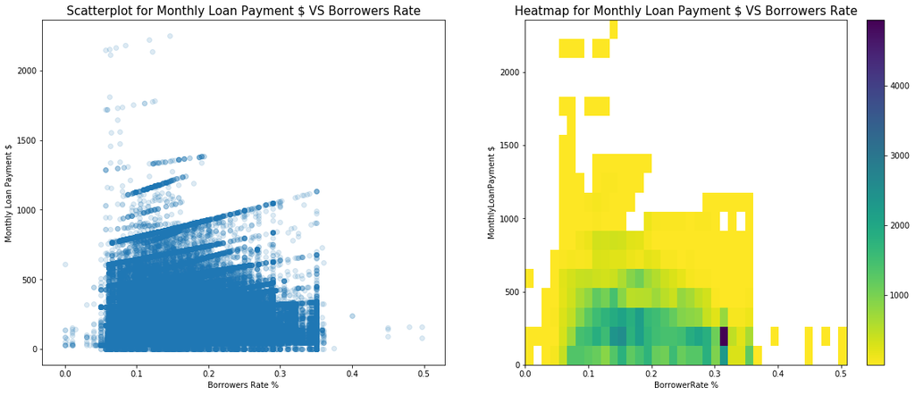

## Numeric Features Correlation

> The Next plot we have is a pairplot showing the correlation between the numeric features in my dataset. We can see a number of interesting features that have a strong positive correlations and some that doesn't.

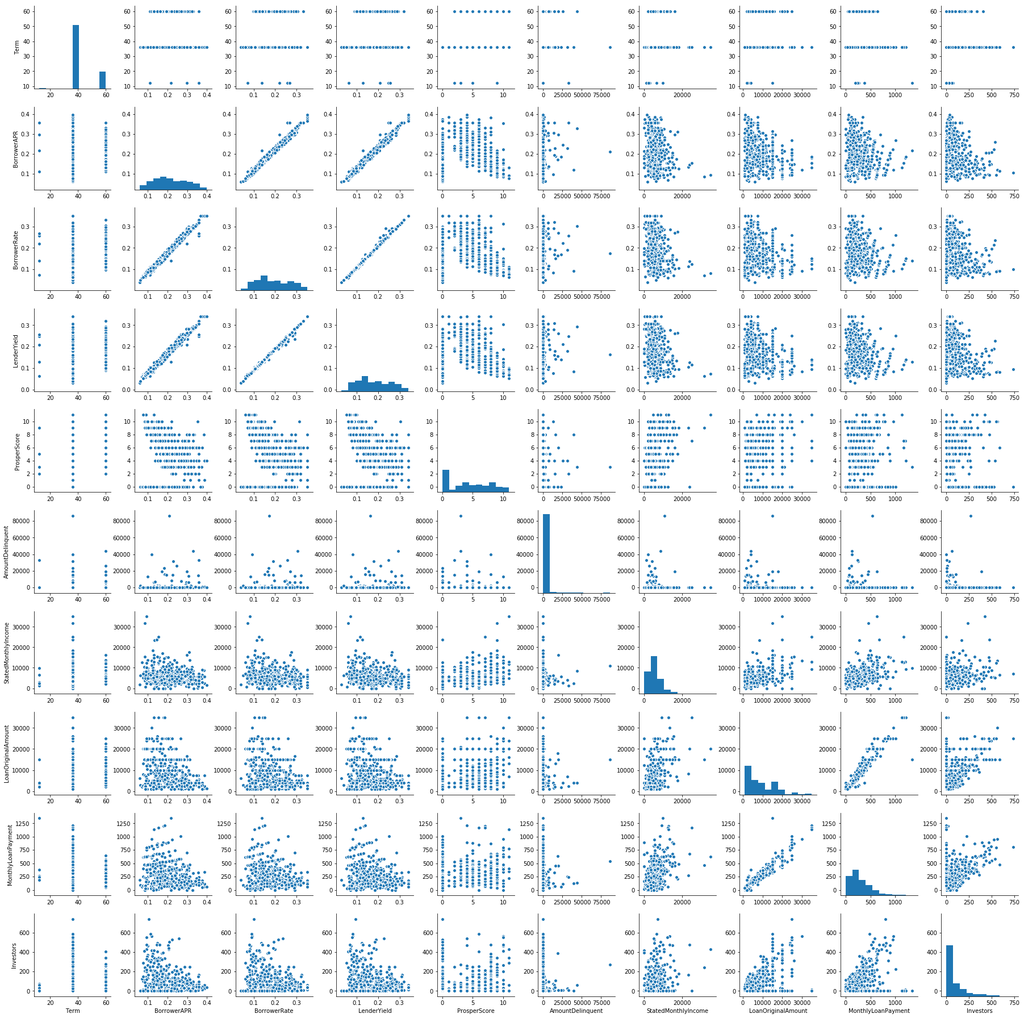

## Loan Original Amount Distribution

> We can deduce from this plot that most of the high Loan Orignal Amount was from people with a high prosper score. In addition, the people with the high prosper had the lowest BorrowerAPR, whereas the people whose prosper score fell within the range of 1 - 4 had a higher BorrowerAPR.

> Also, we can see the desinty of the Loan Orignal Amount lies around 5000 as we have a lot of points with the shade of 5000 on the colorbar in our scatterplot

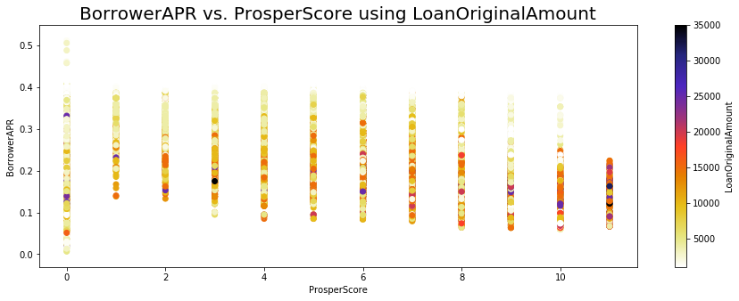